# Untitled

Kiprop Yano

2023-07-20

```r
knitr::opts_chunk$set(echo = TRUE)
```

This is an exploratory data analysis of the dataset provided, which contains monthly data for children under five years old, disaggregated at a county level, spanning from January 2021 to June 2023. In this analysis, I will examine various variables that offer valuable insights into the health and nutrition status of young children in Kenya. The dataset includes information on the total number of children dewormed, cases of acute malnutrition among children under five, instances of diarrhea, and the number of children who are stunted and underweight within specific age brackets.

```r
#Loading necessary packages
library(dplyr)
```

```r
library(tidyr)
library(ggplot2)
```

```r
#Loading the dataset
CEMA_data <- read.csv('https://raw.githubusercontent.com/cema-uonbi/internship_task/main/data/cema_internship_task_2023.csv')

str(CEMA_data)
```

```
## 'data.frame':    1410 obs. of  11 variables:
##  $ period                  : chr  "Jan-23" "Jan-23" "Jan-23" "Jan-23" ...
##  $ county                  : chr  "Baringo County" "Bomet County" "Bungoma County" "Busia County" ...
##  $ Total.Dewormed          : int  3659 1580 6590 7564 1407 3241 6751 4691 790 7532 ...
##  $ Acute.Malnutrition      : int  8 NA 24 NA NA 72 250 9 26 104 ...
##  $ stunted.6.23.months     : int  471 1 98 396 92 326 40 209 51 319 ...
##  $ stunted.0..6.months     : int  34 3 154 143 71 86 13 87 6 102 ...
##  $ stunted.24.59.months    : int  380 NA 23 111 5 24 99 58 50 155 ...
##  $ diarrhoea.cases         : int  2620 1984 4576 2239 2739 1376 2314 2787 1319 4202 ...
##  $ Underweight.0..6.months : int  85 41 231 251 57 141 223 140 13 139 ...
##  $ Underweight.6.23.months : num  739 86 315 608 104 ...
##  $ Underweight.24.59.Months: num  731 16 120 125 21 ...
```

```r
# Data Cleaning: Replace missing values with zeros
CEMA_data[is.na(CEMA_data)] <- 0
```

Part 1: Comparing the Health Indicators by County

Qn. Which counties show the higher or lower values for these health indicators: 1. Total number of children dewormed (Total Dewormed) 2. Number of children <5 years with acute malnutrition (Acute Malnutrition) 3. Number of children stunted (0-6 months, 6-23 months, 24-59 months) 4. Number of children <5 years with diarrhe (Diarrhea cases) 5. Number of children who are underweight (0-6 months, 6-23 months, 24-59 months)

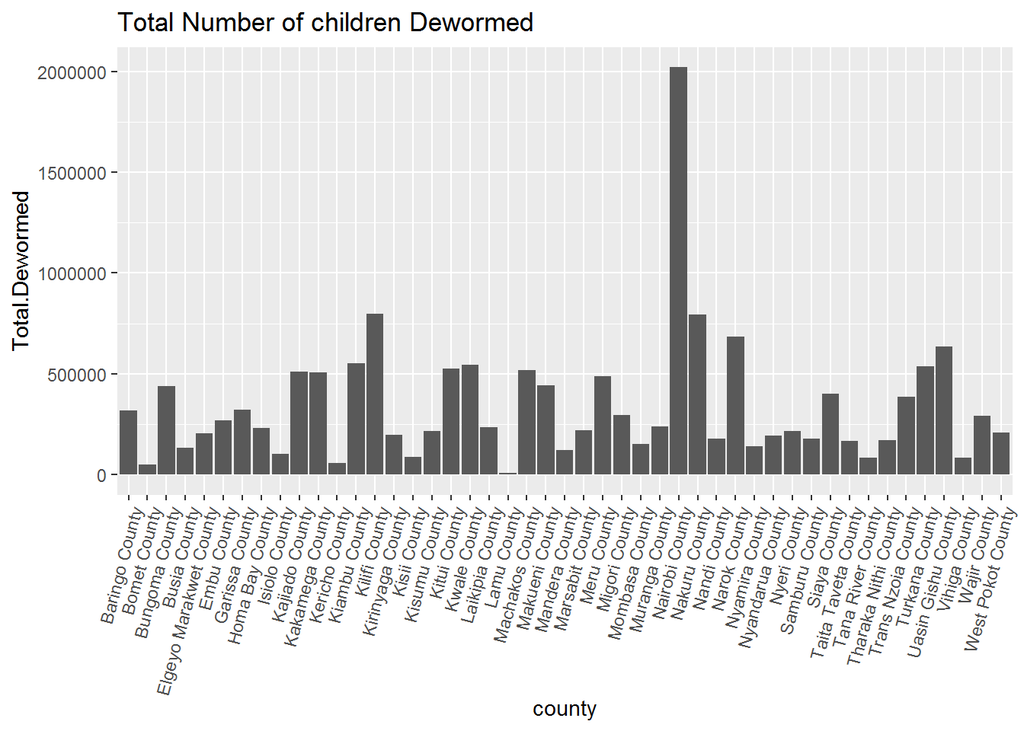

```r
# Function to plot a bar chart with rotated x-axis labels
plot_bar_chart <- function(data, x_col, y_col, title) {
  ggplot(data, aes_string(x = x_col, y = y_col)) +
    geom_col() +
    labs(title = title, x = x_col, y = y_col) +
    theme(axis.text.x = element_text(angle = 75, hjust = 1))

}

# Call the function to plot the bar chart for "Total Dewormed" with rotated labels
plot_bar_chart(CEMA_data, "county", "Total.Dewormed", "Total Number of children Dewormed")
```

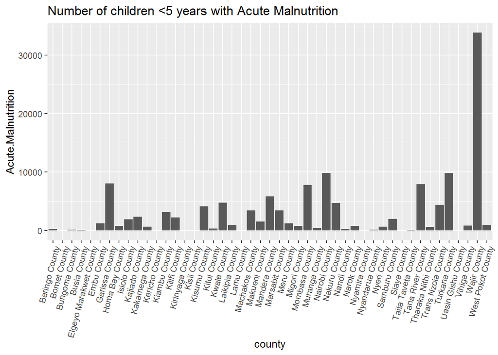

```r
plot_bar_chart(CEMA_data, "county", "Acute.Malnutrition", "Number of children <5 years with Acute Malnutrition")
```

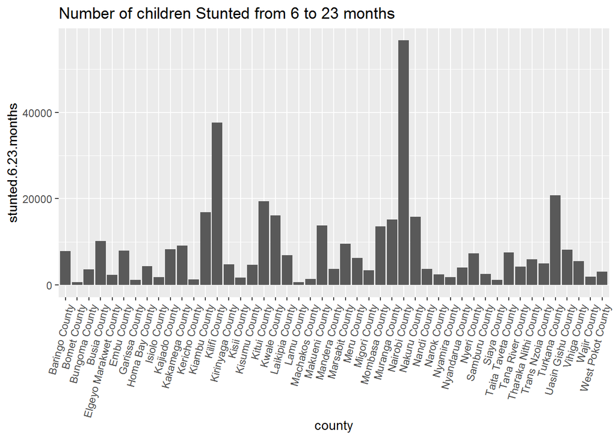

```r
plot_bar_chart(CEMA_data, "county", "stunted.6.23.months", "Number of children Stunted from 6 to 23 months")
```

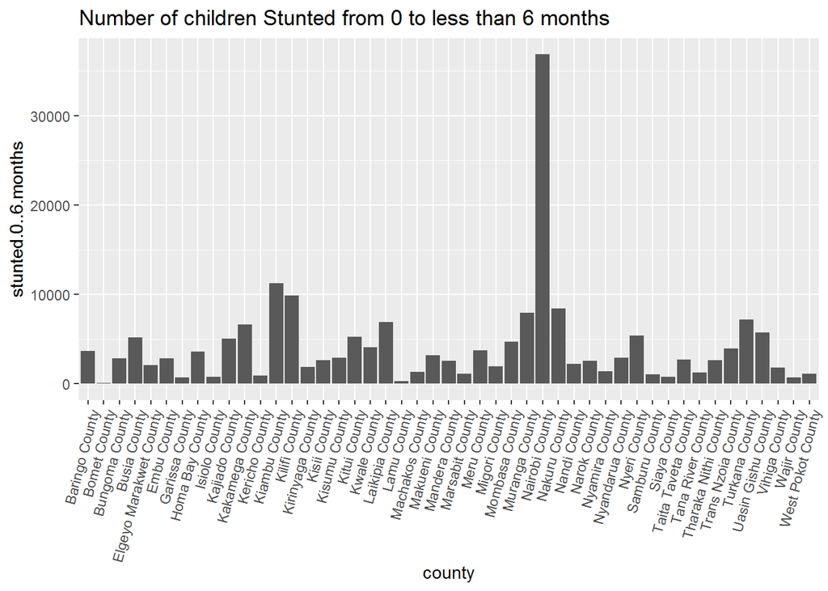

```r
plot_bar_chart(CEMA_data, "county", "stunted.0..6.months", "Number of children Stunted from 0 to less than 6 months")
```

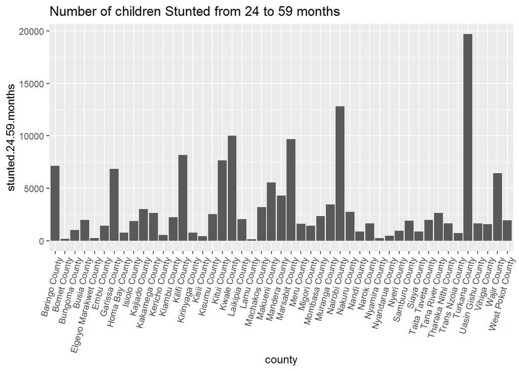

```r
plot_bar_chart(CEMA_data, "county", "stunted.24.59.months", "Number of children Stunted from 24 to 59 months")
```

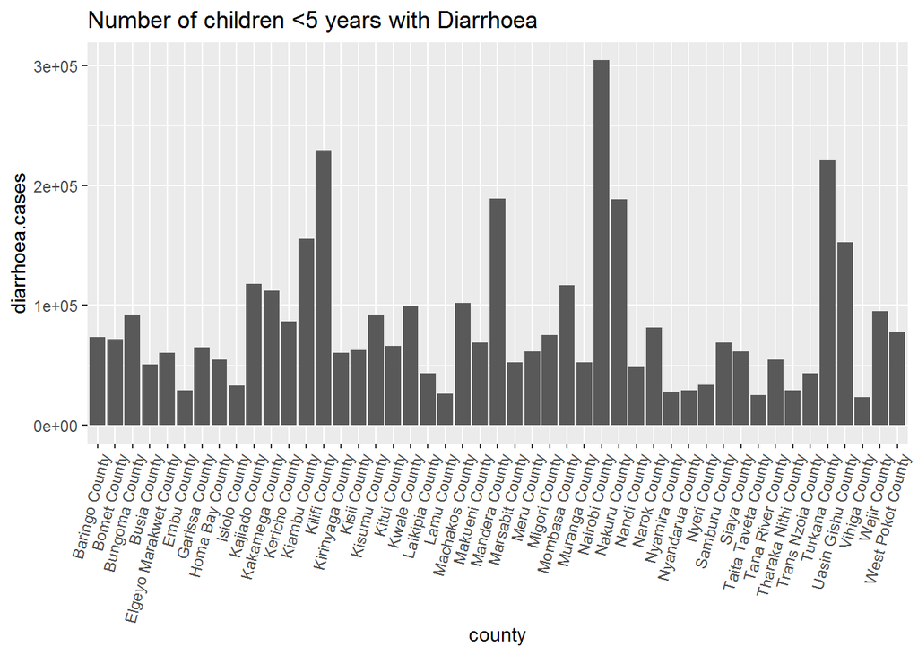

```r
plot_bar_chart(CEMA_data, "county", "diarrhoea.cases", "Number of children <5 years with Diarrhoea")
```

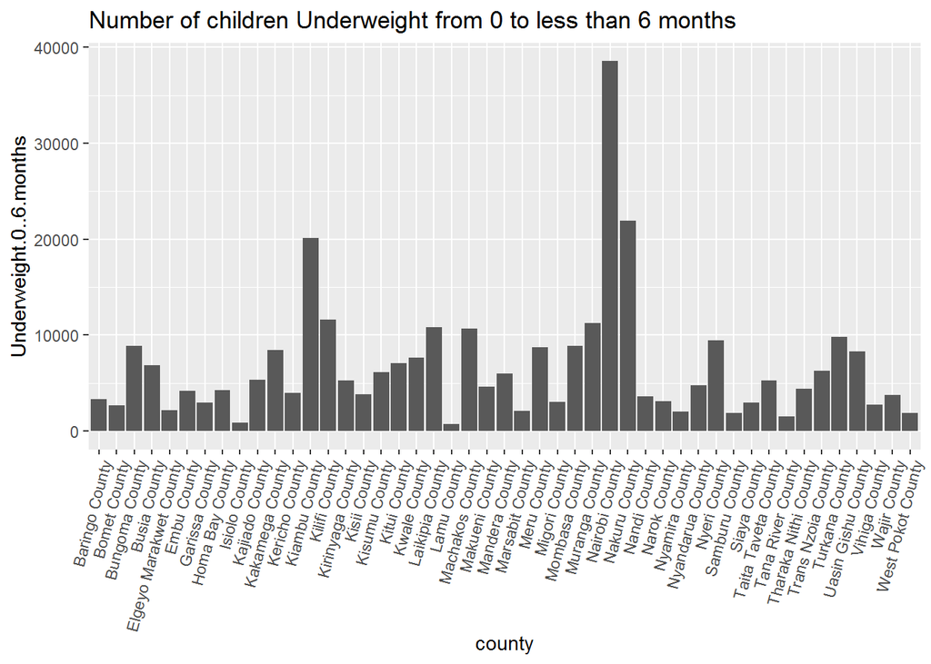

```r
plot_bar_chart(CEMA_data, "county", "Underweight.0..6.months", "Number of children Underweight from 0 to less than 6 months")
```

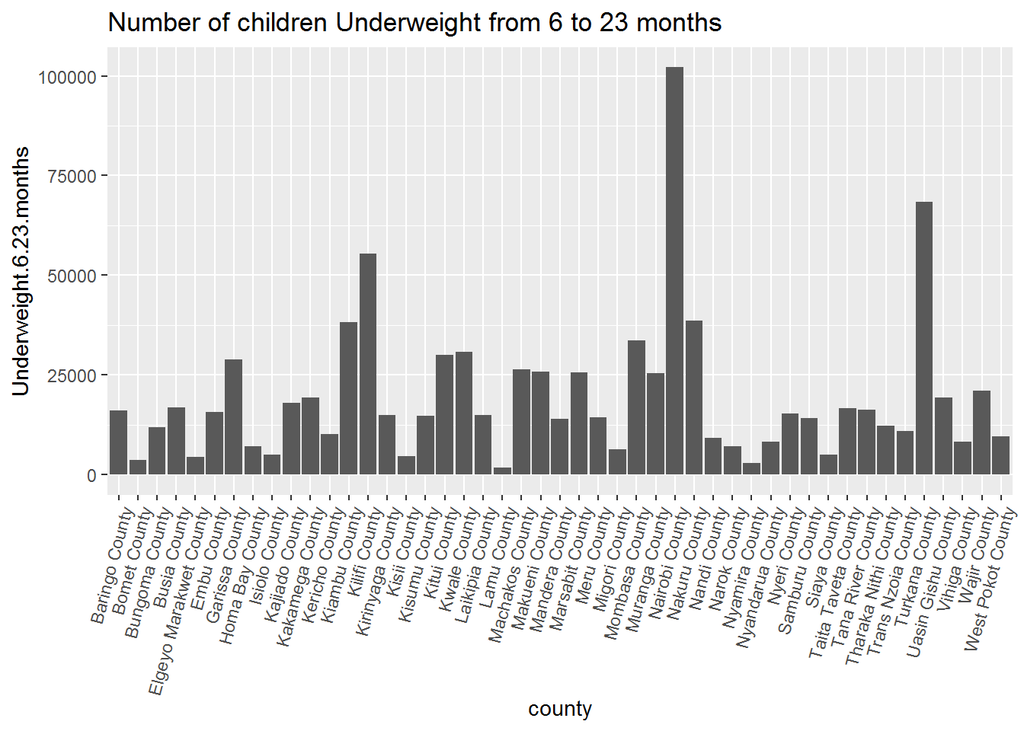

```r
plot_bar_chart(CEMA_data, "county", "Underweight.6.23.months", "Number of children Underweight from 6 to 23 months")
```

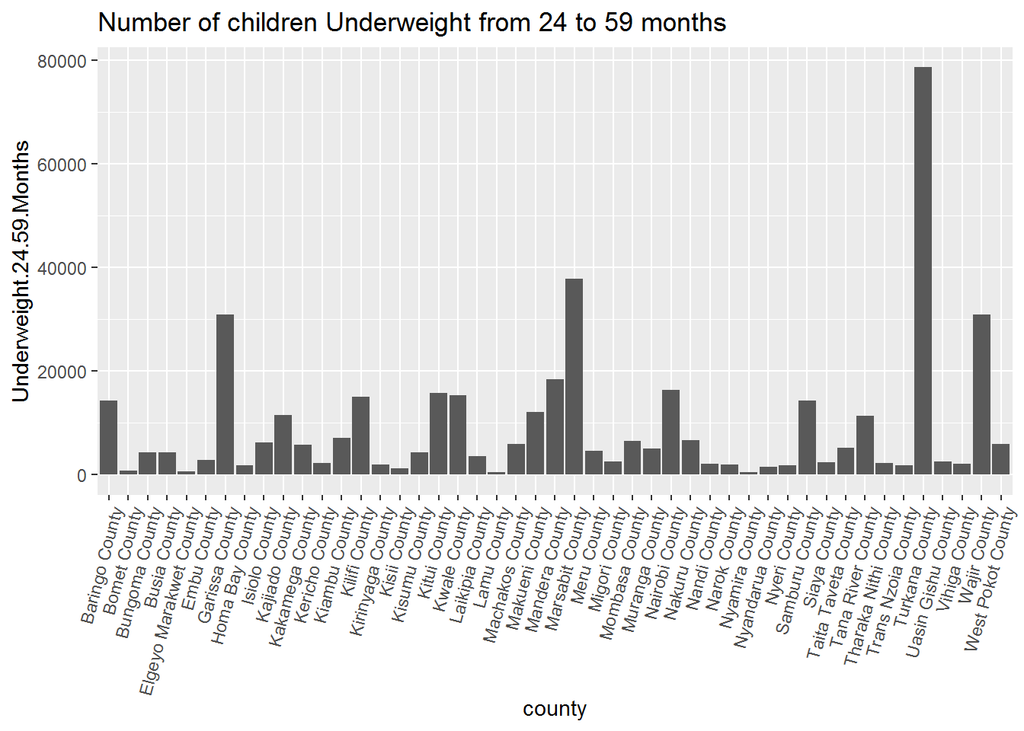

```r
plot_bar_chart(CEMA_data, "county", "Underweight.24.59.Months", "Number of children Underweight from 24 to 59 months")
```

From the observations, it Nairobi County consistently ranks high across several health indicators, such as total deworming, acute malnutrition, stunting, diarrhea cases, and underweight children in different age brackets. On the other hand, Turkana County stands out with the highest number of stunted and underweight children aged 24-59 months.

Part 2: Investigating Child Nutrition Status in different age groups (0-<6 months, 6-23 months, 24-59 months) across the counties.

Qn. Which age group shows higher rates of stunting and underweight? Are there differences in nutritional status between age groups in specific counties?

```r
# Filter the columns related to stunting rates
stunting_data <- CEMA_data %>%
  select(county, contains("stunted"))

# Gather the data to convert it into a tidy format
stunting_data <- stunting_data %>%
  gather(key = "age_group", value = "stunting_rate", -county, na.rm = TRUE) %>%
  mutate(age_group = gsub("stunted ", "", age_group))

# Calculate the average stunting rate for each age group in each county
avg_stunting_data <- stunting_data %>%
  group_by(county, age_group) %>%
  summarise(avg_stunting_rate = mean(stunting_rate, na.rm = TRUE))
```

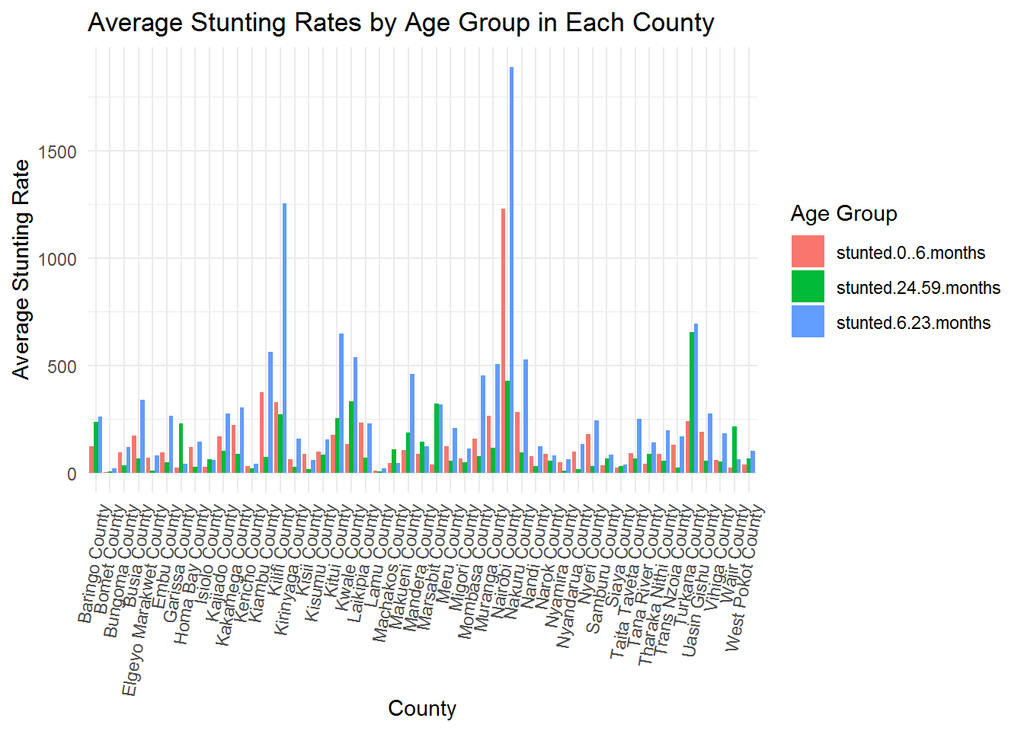

```r
# Create a bar plot for average stunting rates by age group in each county
ggplot(avg_stunting_data, aes(x = county, y = avg_stunting_rate, fill = age_group)) +
  geom_bar(stat = "identity", position = "dodge") +
  labs(title = "Average Stunting Rates by Age Group in Each County",
       x = "County",
       y = "Average Stunting Rate",
       fill = "Age Group") +
  theme_minimal() +
  theme(axis.text.x = element_text(angle = 80, hjust = 1)) +
  scale_fill_discrete(name = "Age Group")
```

```r
# Filter the columns related to underweight rates
underweight_data <- CEMA_data %>%
  select(county, contains("Underweight"))

# Gather the data to convert it into a tidy format
underweight_data <- underweight_data %>%
  gather(key = "age_group", value = "underweight_rate", -county, na.rm = TRUE) %>%
  mutate(age_group = gsub("Underweight ", "", age_group))

# Calculate the average underweight rate for each age group in each county
avg_underweight_data <- underweight_data %>%
  group_by(county, age_group) %>%
  summarise(avg_underweight_rate = mean(underweight_rate, na.rm = TRUE))
```

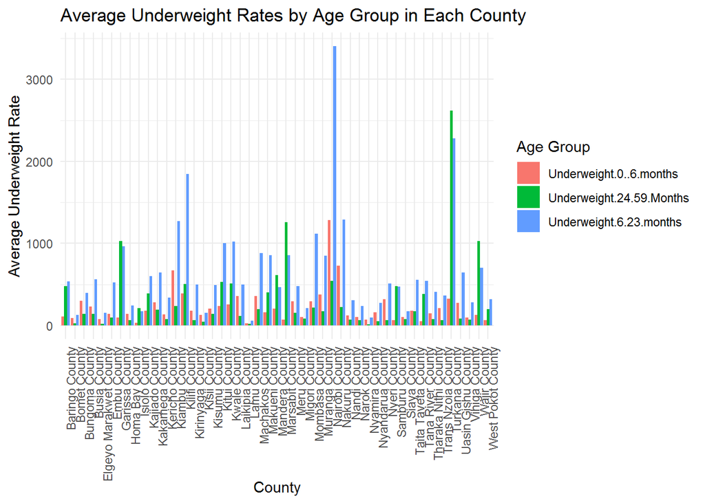

```r
# Create a bar plot for average underweight rates by age group in each county
ggplot(avg_underweight_data, aes(x = county, y = avg_underweight_rate, fill = age_group)) +
  geom_bar(stat = "identity", position = "dodge") +
  labs(title = "Average Underweight Rates by Age Group in Each County",
       x = "County",
       y = "Average Underweight Rate",
       fill = "Age Group") +
  theme_minimal() +
  theme(axis.text.x = element_text(angle = 90, hjust = 1)) +
  scale_fill_discrete(name = "Age Group")
```

This suggests that children in the 6-23 months age group in Nairobi County may be facing higher nutritional challenges, with a higher proportion of them experiencing stunting and underweight compared to other age groups and counties.

Part 3: Finding the Correlation between Health Indicators

Qn: Is there a correlation between acute malnutrition and stunting in children? Qn: Are there any associations between deworming efforts and reduced malnutrition rates?

Qn 1. Is there a correlation between acute malnutrition and stunting in children?

```r
# Select the columns for acute malnutrition and stunting
nutrition_data <- CEMA_data %>%
  select(Acute.Malnutrition, starts_with("stunted"))

# Remove rows with missing values in the selected columns
nutrition_data <- nutrition_data %>%
  na.omit()
```

```r
# Calculate the correlation coefficient between Acute Malnutrition and stunting variables
correlation_coefficient <- cor(nutrition_data$Acute.Malnutrition, nutrition_data$stunted.0..6.months)
# Print the correlation coefficient
print(correlation_coefficient)
```

```
## [1] 0.09051677
```

Here, the correlation coefficient is 0.0905 which indicates a weak positive linear relationship between Acute Malnutrition and stunting variables. This means that there is a very slight tendency for the two variables to increase together, but the relationship is not strong.

Qn 2. Are there any associations between deworming efforts and reduced malnutrition rates?

To investigate any associations between deworming efforts and reduced malnutrition rates, we can use scatter plots to visualize the relationship between the total number of children dewormed and the rates of acute malnutrition, stunting, and underweight.

```r
# Select the columns for total dewormed, acute malnutrition, stunting, and underweight
deworming_data <- CEMA_data %>%
  select(Total.Dewormed, Acute.Malnutrition, starts_with("stunted"), starts_with("Underweight"))

# Remove rows with missing values in the selected columns
deworming_data <- deworming_data %>%
  na.omit()
```

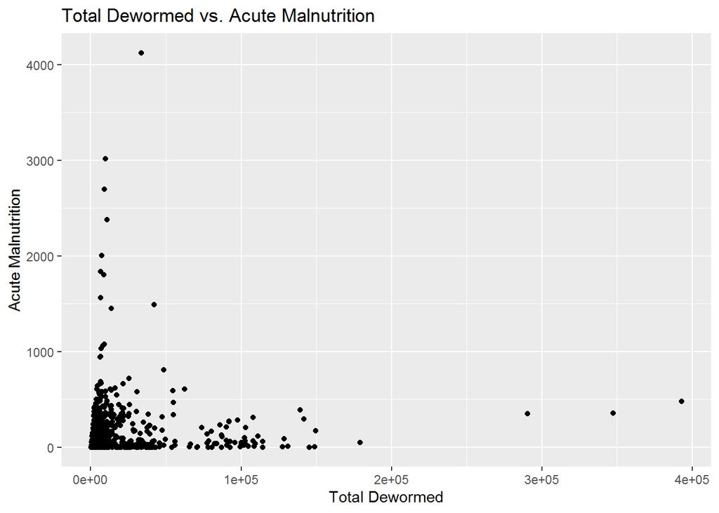

```r
# Scatter plot of Total Dewormed vs. Acute Malnutrition
ggplot(deworming_data, aes(x = Total.Dewormed, y = Acute.Malnutrition)) +
  geom_point() +
  labs(title = "Total Dewormed vs. Acute Malnutrition",
       x = "Total Dewormed",
       y = "Acute Malnutrition")
```

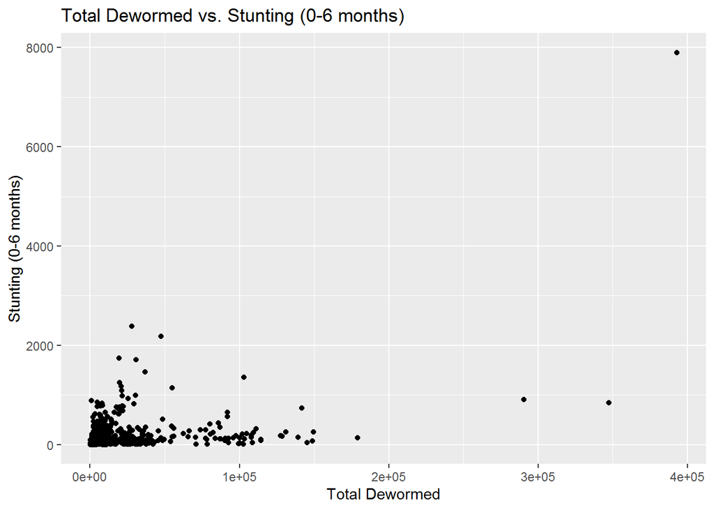

```r
# Scatter plot of Total Dewormed vs. Stunting
ggplot(deworming_data, aes(x = Total.Dewormed, y = stunted.0..6.months)) +
  geom_point() +
  labs(title = "Total Dewormed vs. Stunting (0-6 months)",
       x = "Total Dewormed",
       y = "Stunting (0-6 months)")
```

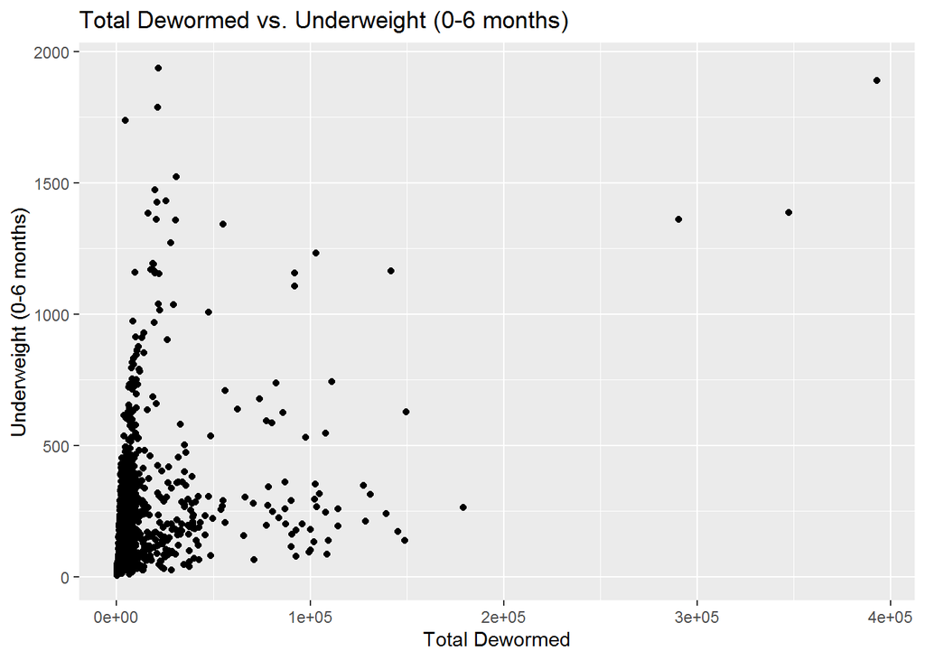

```r
# Scatter plot of Total Dewormed vs. Underweight
ggplot(deworming_data, aes(x = Total.Dewormed, y = Underweight.0..6.months)) +
  geom_point() +
  labs(title = "Total Dewormed vs. Underweight (0-6 months)",
       x = "Total Dewormed",
       y = "Underweight (0-6 months)")
```